# Cross-fertilizing weed science and plant invasion science to improve efficient management: A European challenge - ScienceDirect

[figure not shown]

## Outline

1. Abstract
2. Keywords
3. Weed science vs. plant invasion science in Europe: different history and different focus with regard to management
4. Crop weeds vs. invasive alien plants
5. Common ragweed, an ideal ‘bridge species’
6. Enabling synergies by inter-linking weed science with plant invasion science, and by inter- and trans-disciplinary cooperation
7. SMARTER — a template for a more efficient and sustainable management of invasive plants and weeds: achievements, limitations and the way forward
8. Acknowledgements
9. Appendix A. Supplementary data
10. References

## Cited By (19)

## Figures (1)

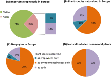

## Extras (2)

[figure not shown]

## [Basic and Applied Ecology](https://www.sciencedirect.com/journal/basic-and-applied-ecology)

[Volume 33](https://www.sciencedirect.com/journal/basic-and-applied-ecology/vol/33/suppl/C), December 2018, Pages 1-13

# Opinion Paper Cross-fertilizing weed science and plant invasion science to improve efficient management: A European challenge

[H.Müller-Schärer<sup>a</sup>](https://www.sciencedirect.com/science/article/abs/pii/S1439179118300434#!)[Y.Sun<sup>a</sup>](https://www.sciencedirect.com/science/article/abs/pii/S1439179118300434#!)[B.Chauvel<sup>b</sup>](https://www.sciencedirect.com/science/article/abs/pii/S1439179118300434#!)[G.Karrer<sup>c</sup>](https://www.sciencedirect.com/science/article/abs/pii/S1439179118300434#!)[G.Kazinczi<sup>d</sup>](https://www.sciencedirect.com/science/article/abs/pii/S1439179118300434#!)[P.Kudsk<sup>e</sup>](https://www.sciencedirect.com/science/article/abs/pii/S1439179118300434#!)[A.G.J.M. LansinkOude<sup>f</sup>](https://www.sciencedirect.com/science/article/abs/pii/S1439179118300434#!)[U.Schaffner<sup>g</sup>](https://www.sciencedirect.com/science/article/abs/pii/S1439179118300434#!)[C.A.Skjoth<sup>h</sup>](https://www.sciencedirect.com/science/article/abs/pii/S1439179118300434#!)[M.Smith<sup>i</sup>](https://www.sciencedirect.com/science/article/abs/pii/S1439179118300434#!)[M.Vurro<sup>j</sup>](https://www.sciencedirect.com/science/article/abs/pii/S1439179118300434#!)[L.A.de Weger<sup>k</sup>](https://www.sciencedirect.com/science/article/abs/pii/S1439179118300434#!)[S.T.E.Lommen<sup>a</sup>](https://www.sciencedirect.com/science/article/abs/pii/S1439179118300434#!)

https://doi.org/10.1016/j.baae.2018.08.003[Get rights and content](https://s100.copyright.com/AppDispatchServlet?publisherName=ELS&contentID=S1439179118300434&orderBeanReset=true)

## Abstract

Both weed science and plant invasion science deal with noxious plants. Yet, they have historically developed as two distinct research areas in Europe, with different target species, approaches and management aims, as well as with diverging institutions and researchers involved. We argue that the strengths of these two disciplines can be highly complementary in implementing management strategies and outline how synergies were created in an international, multidisciplinary project to develop efficient and sustainable management of common ragweed, *[Ambrosia artemisiifolia](https://www.sciencedirect.com/topics/agricultural-and-biological-sciences/ambrosia-artemisiifolia)*. Because this species has severe impacts on human health and is also a crop weed in large parts of Europe, common ragweed is one of the economically most important plant invaders in Europe. Our multidisciplinary approach combining expertise from weed science and plant invasion science allowed us (i) to develop a comprehensive plant demographic model to evaluate and compare management tools, such as optimal cutting regimes and biological control for different regions and habitat types, and (ii) to assess benefits and risks of biological control. It further (iii) showed ways to reconcile different stakeholder interests and management objectives (health versus crop yield), and (iv) led to an economic model to assess invader impact across actors and domains, and effectiveness of control measures. (v) It also led to design and implement management strategies in collaboration with the various stakeholder groups affected by [noxious weeds](https://www.sciencedirect.com/topics/agricultural-and-biological-sciences/noxious-weed), created training opportunities for early stage researchers in the sustainable management of noxious plants, and actively promoted improved decision making regarding the use of exotic [biocontrol agents](https://www.sciencedirect.com/topics/earth-and-planetary-sciences/biocontrol-agent) at the national and European level. We critically discuss our achievements and limitations, and list and discuss other potential Old World (Afro-Eurasian) target species that could benefit from applying such an integrative approach, as typical invasive alien plants are increasingly reported from [crop fields](https://www.sciencedirect.com/topics/agricultural-and-biological-sciences/field-crops) and native crop weeds are invading adjacent non-crop land, thereby forming new source populations for further spread.

## Keywords

Integrated weed management

Biological weed control

Plant invasion

*Ambrosia artemisiifolia*

Interdisciplinary and international research cooperation

## Cited by (19)

### Fighting neobiota with neobiota: Consider it more often and do it more rigorously

- 2022, Biological Conservation

### Ground-truthing predictions of a demographic model driven by land surface temperatures with a weed biocontrol cage experiment

- 2022, Ecological Modelling

### Assessing the risks of non-target feeding by the accidentally introduced ragweed leaf beetle, Ophraella communa, to native European plant species

- 2020, Biological Control

### How to better predict long-term benefits and risks in weed biocontrol: an evolutionary perspective

- 2020, Current Opinion in Insect Science

### Invasive alien plant species: Their impact on environment, ecosystem services and human health

- 2020, Ecological Indicators

### Predicting abundances of invasive ragweed across Europe using a “top-down” approach

- 2019, Science of the Total Environment

  Citation Excerpt :

  These variations are in part related to the regional distribution of ecosystems likely to be affected and partly associated with factors, such as steep terrain or specific agricultural management schemes, that suppress the level of ragweed invasion. The inventory is a major synthesis from COST Action FA1203-SMARTER for the “Sustainable management of Ambrosia artemisiifolia in Europe” (Müller-Schärer et al., 2018); a large EU-funded network that operated from 2012 to 2016 with >250 active scientists from over 30 countries (Müller-Schärer et al., 2018). The data collected within SMARTER is, to the best of our knowledge, the largest amount of Ambrosia pollen data ever collected.

[figure not shown]

[figure not shown]